# Questionable Research Practices

Week 11

Dr Jenny Terry & Dr Martina Sladekova

# Part 1: How science got broken

## How Psychology joined Science…

1879 - world’s psychology lab established by Wilhelm Wundt

- Defining point for Psychology as a separate discipline
- Prior to that - part of philosophy
- Use of experimental methods for the first time - smooth psychological science followed

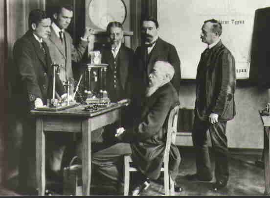

## And then 💩 hit the fan…

Open Science Collaboration (2015): **Estimating the reproducibility of psychological science**

- Attempted to replicate findings published in high profile journals
- Replicated effect sizes were half the size of the ones than originally reported
- 97% of original *p*-values were statistically significant (*p* < 0.05)
- Only 36% of replicated *p*-values were statistically significant

**Vocabulary**

**Replication:** The process of repeating (re-running) the same study using identical methodology.

## And then 💩 hit the fan…

Some famous findings that we **can’t** replicate:

- Smiling will make you feel happier
- Power posing will make you act bolder
- Self-control is a limited resource (ego-depletion)
- Revising after your exams can improve your earlier performance (Daryl Bem’s “pre-cognition” experiments)
- Babies are born with the ability to imitate

[figure not shown]

Read more here: https://www.bps.org.uk/research-digest/ten-famous-psychology-findings-have-been-difficult-replicate

## What should get published?

> Two teams of researchers set out to study the effect of mindfulness meditation on well-being. Both teams apply the same intervention using identical protocol and each team collects 200 participants. The teams analyse their own data using the *t*-test, comparing the well-being of the intervention group against the control group.

**Team 1**

Team 1 finds a statistically **significant difference** in well-being between the two groups (*p* = .034)

**Team 2**

Team 2 finds a **non-significant difference** in well-being between the two groups (p = .27)

Both teams write-up their reports as a scientific paper. **Which paper should get published?**

## Publication bias

- Some results are more “interesting” to publish (more readers and citations = more money)
- The publication record is over-populated with statistically significant findings
- Papers with significant *p*-values are 9 times more likely to get published
- Problem for evidence synthesis/meta-analysis
  - **Weakness of statistical research:** if there is no effect of mindfulness on well-being, we’ll still find a statistically significant result in 5% of replications because of random sampling (assuming alpha of 0.05)

**Vocabulary**

**Publication bias** or the “File drawer effect” - is the bias in the publication system where statistically significant results are favoured for publication over non-significant findings. Papers reporting non-significant findings often end up in researchers’ file-drawers, never to be seen again.

## A day in the life of a scientist

- Conduct research (requires funding)
- Train research students (requires funding)
- Publish papers (requires funding)
- Teach (it’s free! 🤩)
- Secure funding (apply for grants)

Funding bodies look at researchers’ publication records (among other things) to decide who gets awarded a grant.

Failure to publish |> failure to secure funding |> failure to conduct further research |> job insecurity

## Questionable Research Practices (QRPs)

Tight deadlines +

high pressure competitive environment +

“publish or perish” +

lack of training +

personal investment -> **QRPs**

**Vocabulary**

**Questionable research practices** - a range of practices that distort (intentionally or unintentionally) the results (often) motivated by the desire to find support for hypotheses and make research more publishable.

## Questionable Research Practices (QRPs)

From UK Research Integrity Office:

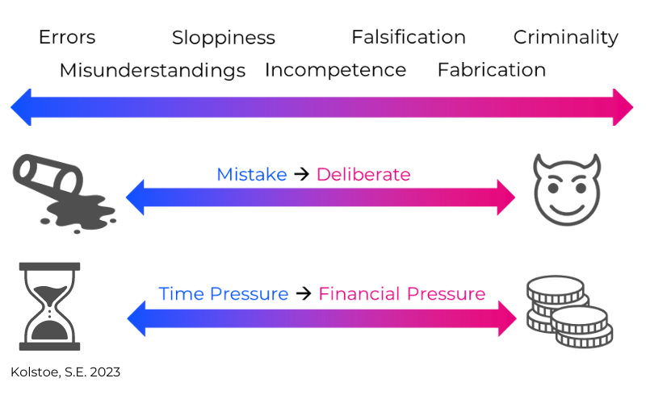

Hanlon’s Razor: “Never attribute to malice that which is adequately explained by ignorance or incompetence.”

## The Garden of Forking Paths

- Each analysis has many decision points - which tests to run, which participants to exclude, which steps to take during data cleaning, etc..
- Each decision results in a unique analysis “path”
- Different analysts might not necessarily take the same path and arrive at the same conclusion (Silberzahn, 2018)
- Some “paths” become can *seem* more sensible depending on your motivations

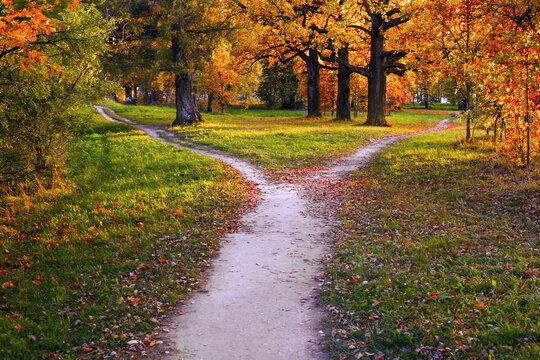

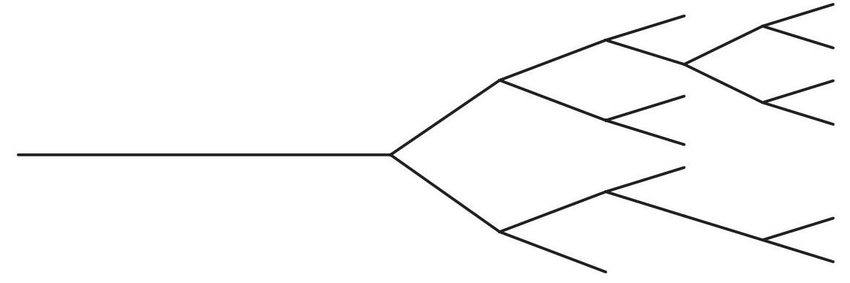

## Some QRPs

### *p*-hacking

- Selective inclusion/removal of cases
- Subsetting/combining groups
- Variable dichotomisation
- Data transformation
- Collecting more data (“data peeking”)

**NOTE:** None of these are “questionable” in their own right. Motivation matters!

**Vocabulary**

*p*-hacking: taking specific analytic steps in order to achieve statistical significance rather than (pre-planned) steps that are more appropriate to answer the research question.

## Some QRPs

### *p*-hacking

Masicampo, E. J., & Lalande, D. R. (2012). A peculiar prevalence of *p* values just below .05:

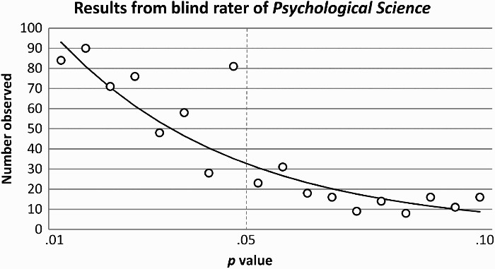

## Some QRPs

### HARKing

- NOT the same as exploratory research
- NOT the same as discussing explanations for your (suprising) results

**Vocabulary**

**HARKing**: Hypothesizing After The Results are Known. Often involves collecting data without clear a hypothesis, deciding on a hypothesis based on what’s significant, and then presenting that hypothesis as if it was decided on *before* running any analyses.

## Some QRPs

### Selective reporting

- Often goes hand-in-hand with HARKing
- Collecting a lot of variables and only reporting statistically significant relationships (without making in clear that you’ve also collected other data)

### Selective/inaccurate citing

- Picking and choosing which papers to cite in a way that fit your narrative
- Citing papers as supporting a specific point when they don’t

### Salami slicing

- Splitting relevant analyses from a single dataset into multiple papers to increase publication count

## Do Psychologists Engage in QRPs? (John et al. 2012)

| Item | Self admission rate (%) |
| --- | --- |
| Failing to report all of study’s dependent measures | 63.4 |
| Deciding whether to collect more data after looking to see whether the results were significant | 55.9 |
| Failing to report all of a study’s conditions | 27.7 |
| Stopping collecting data earlier than planned because one found the result that one had been looking for | 16.6 |
| “Rounding off” a p value (e.g., reporting that a p value of .054 is less than .05) | 22.2 |
| Selectively reporting studies that “worked” | 45.8 |
| Deciding whether to exclude data after looking at the impact of doing so on the results | 38.2 |
| Reporting an unexpected finding as having been predicted from the start | 27.0 |
| Claiming that results are unaffected by demographic variables (e.g., gender) when one is actually unsure (or knows that they do) | 3.0 |
| Falsifying data | 0.6 |

## There is yet hope…

PhD Researchers’ beliefs about null results (Pownall et al., 2023):

| Statement | Percent agree: |
| --- | --- |
| If someone does good scientific work, they produce significant results. | 7.98 |
| I believe that null effects are generally caused by sloppy experimental work. | 1.60 |
| A null effect tells me that I did not do good work. | 1.60 |
| Whether I get positive feedback on my work depends on whether my results are significant. | 22.34 |
| If my thesis does not produce significant results, I will get more negative feedback. | 25.00 |
| I think my supervisor gives more positive feedback on significant results than non-significant ones. | 22.87 |

## The future of QRPs?

**Risks of AI for research integrity** (Chen et al. 2024):

- Generation of fictitious data
- Data fabrication and falsification
- Inappropriate application of statistical models
- AI-assisted academic plagiarism and automatic content generation
- Lack of transparency and disclosure

## Why should you care?

**YOU** are the future

- researchers (academic or industry)
- practitioners
- educators

Understanding how research works (and how the environment can affects the research process) allows you to:

1. Be critical when you’re reading about research and not fall every “Psychology says” or “Science says” click-bait and
2. Make science better!

**How can we make science better?**

# Part 2: From “Replication Crisis” to “Credibility Revolution”

## The Credibility Revolution

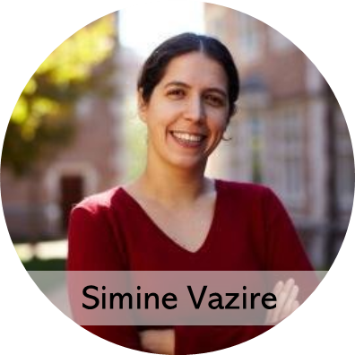

**Simine Vazire** (University of Melbourne)

- Coined the term “Credibility Revolution” to describe a more optimistic move towards improving research, as opposed to just pointing out what was wrong with it
- Co-Founder of the [Society for the Improvement of Psychological Science](https://improvingpsych.org/) (SIPS) in 2016
- SIPS aims to “bring together scholars working to improve methods and practices in psychological science” and has played a key role in the development and proliferation of Open Science

## Open Science (OS)

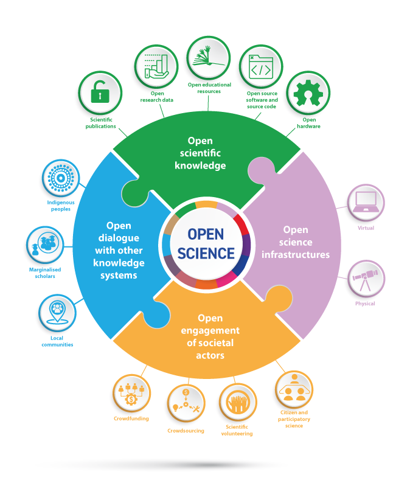

Openness (**transparency**) prevents researchers from being able to hide their QRPs

The Open Science movement has inspired many innovations in transparent research, only a few of which we’ll explore today:

- **Preregistration**
- **Registered reports**
- **Open materials/data/code**

## Preregistration

- [Preregistration](https://www.cos.io/initiatives/prereg) involves publicly sharing a time-stamped research plan (e.g., on the OSF) that includes:
  - *Precise* hypotheses to **prevent HARKing**
  - Information about *all* your variables and how they’re operationalised to **prevent selective reporting**
  - A *detailed* data analysis plan to **prevent *p*-hacking**
- Other benefits include making sure you are collecting data you can actually analyse and front-loading a lot of the work

[figure not shown]

## Registered Reports

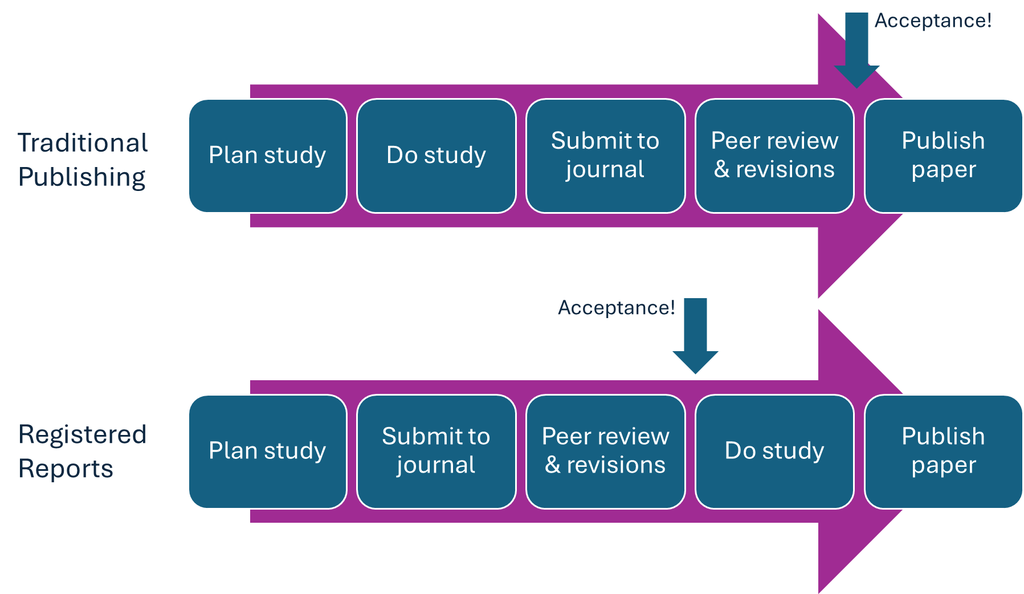

## Registered Reports

[Registered Reports](https://www.cos.io/initiatives/registered-reports) are like preregistration insomuch as you’re specifying what you’re going to do in advance, but they have additional benefits.

- Like preregistration, they aim to **reduce QRPs** such as HARKing, *p*-hacking, and selective reporting
- They also **improve research quality** more generally as the methods are reviewed by peers before data collection commences
- They are also more likely to **reduce publication bias** as journals agree to publish the study based on the quality of the methods, regardless of the results

## Sharing of Materials, Data, & Code

- **Open materials** allow other researchers to inspect and more easily replicate your research study
- **Open code and data** allow other researchers to inspect and reproduce your research findings
- Open code is the main reason **why we’re teaching you R!**

[figure not shown]

# So, has Open Science improved Psychology?

## New Evidence that OS is Improving Psychological Science!

- [Protzko et al. (2023)](https://www.nature.com/articles/s41562-023-01749-9) claimed that **OS efforts are improving replicability**
- Methods are complex, but essentially **compared the replication rates** of studies that had used OS practices with the replication rate of studies that hadn’t used OS practices
- Concluded **86% replication rate** in the OS sample was due to “rigor-enhancing practices” such as **preregistration**, **methodological transparency**, confirmatory tests, and large sample sizes.

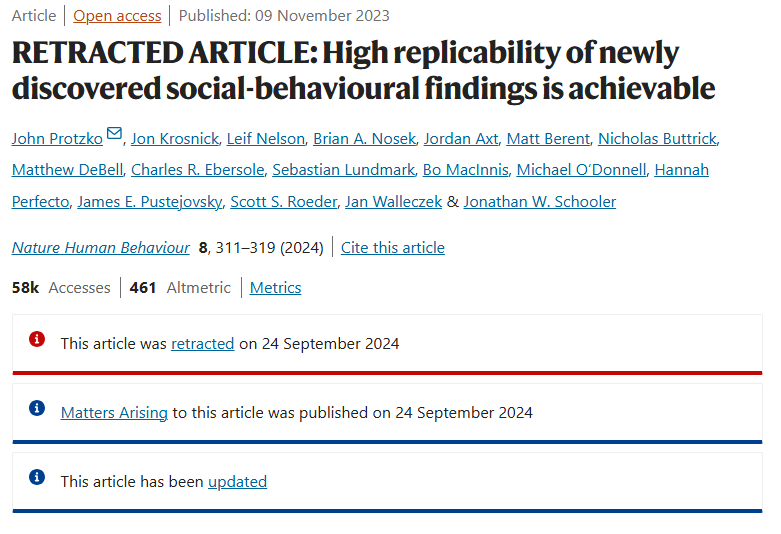

## Wait, what’s that Retraction Notice all about?

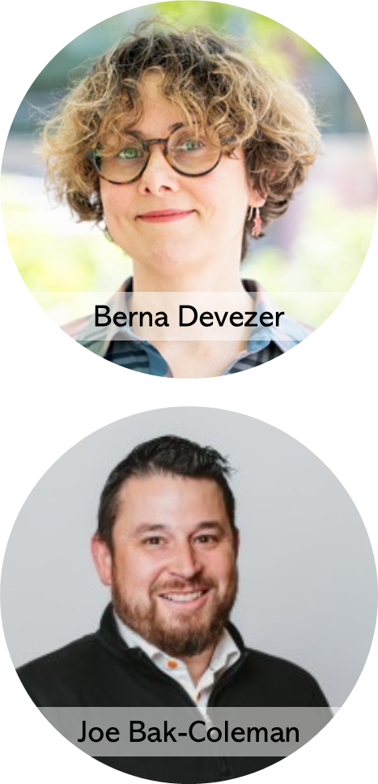

[Bak-Coleman & Devezer (2023)](https://osf.io/preprints/psyarxiv/5u3kj) wrote a response, arguing (amongst other things):

- The definition of ‘replication’ was less conservative in the OS than the non-OS sample
- The OS group of studies were chosen *because* they were more likely to replicate
- The hypotheses and analyses in the study were not as preregistered

The story unfolds further in [this blogpost](https://statmodeling.stat.columbia.edu/2024/03/27/the-feel-good-open-science-story-versus-the-preregistration-who-do-you-think-wins/).

## Wait, what’s that Retraction Notice all about?!

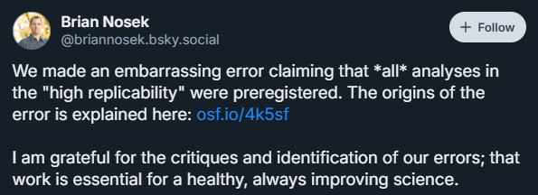

## Wait, what’s that Retraction Notice all about?!

[figure not shown]

## Metabias

[figure not shown]

## Questionable Metascience Practices

[Rubin (2023)](https://journal.trialanderror.org/pub/questionable-metascience-practices/release/4) argued that many OS proponents engage in questionable metascience practices, for example:

- A **lack of evidence** of its efficacy
- **Metabias** towards blaming researcher bias (QRPs) for the replication crisis, when there are other explanations (e.g., weak theory, poor measurement practice)
- Rejecting, undermining, and **ignoring criticisms** of metascience and/or science reform
- Quick, superficial, dismissive, and/or mocking style of criticising others, predominantly from those in positions of **power and privilege** (**bropen science**)

## What do (most of) these OS proponents have in common?

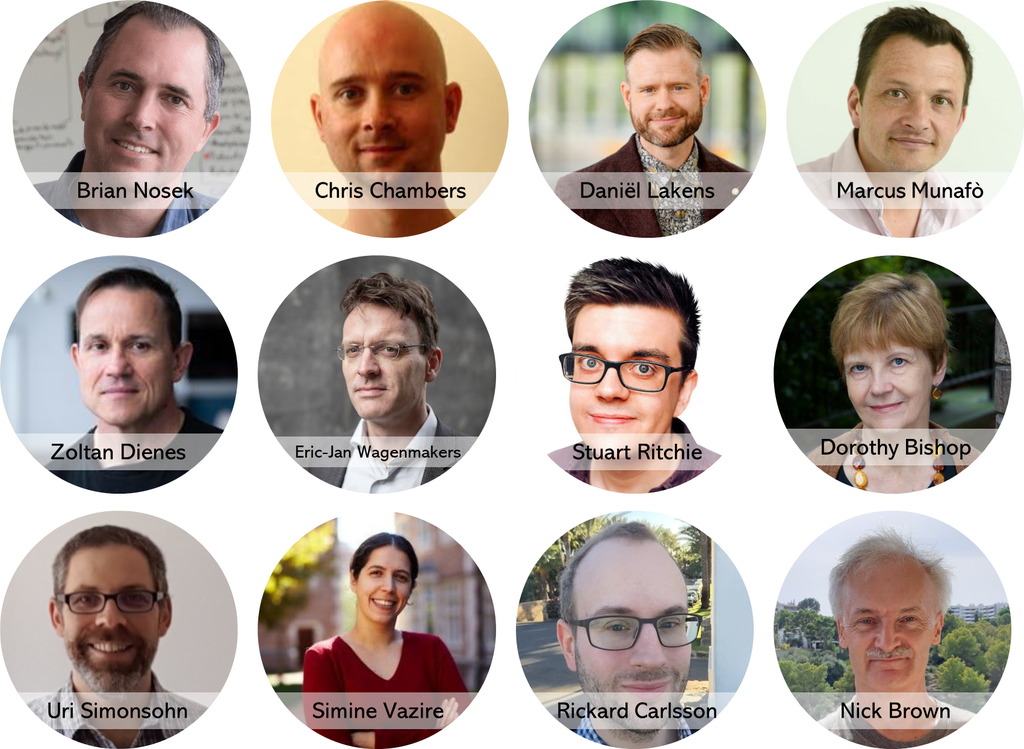

## What do (most of) these OS critics have in common?

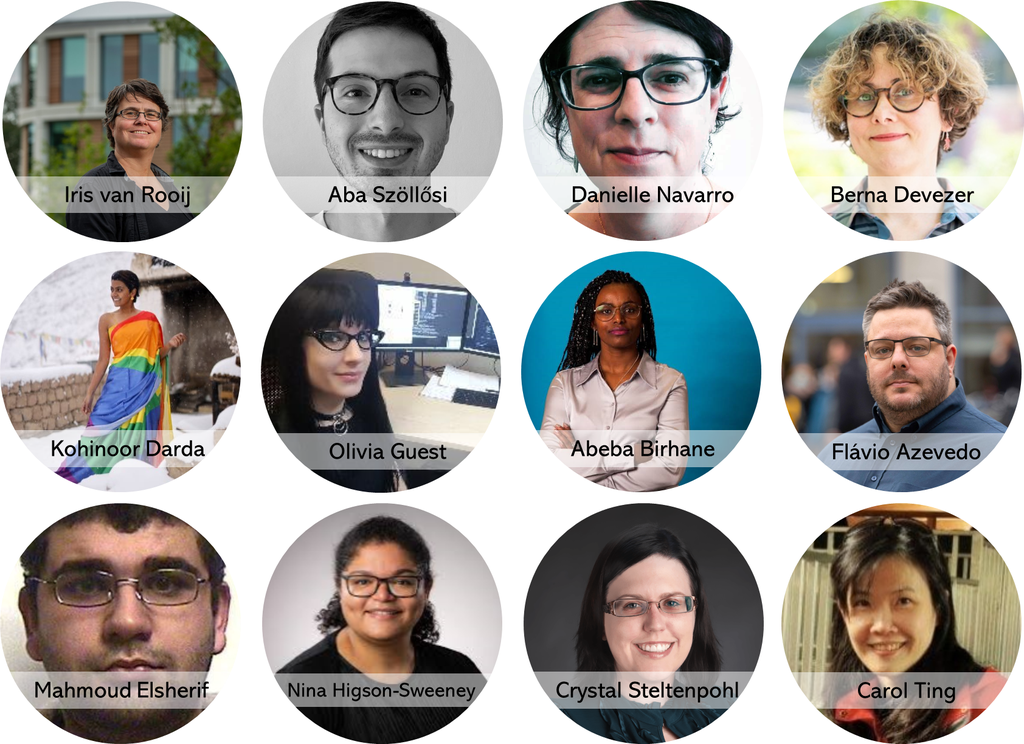

## Bropen Science

[Whitaker & Guest (2020)](https://www.bps.org.uk/psychologist/bropenscience-broken-science)

“Not all bros are men… but they are more likely to be from one or more of the following **dominant social groups**: male, white, cisgender, heterosexual, able-bodied, neurotypical, high socioeconomic status, English-speaking. That’s because **structural privileges exist that benefit certain groups** of people.”

“**#bropenscience** is a tongue-in-cheek expression but also has a serious side, shedding light on the **narrow demographics** and **off-putting behavioural patterns** seen in open science.”

## Glimmers of Hope

- [The Society for the Improvement of Psychological Science’s Code of Conduct](https://improvingpsych.org/mission/) warns against behaviour typical of #bropenscience and is now (visibly) more committed to diversity and inclusion
- [The Center for Open Science’s Symposium: Critical Perspectives on the Metascience Reform Movement](https://www.youtube.com/watch?v=7o6Cabkj8lk) is an example of OS embracing criticism
- Non-English speaking OS groups are being set up which challenge and dilute the dominant Western narrative, such as the [Chinese Open Science Network](https://journals.sagepub.com/doi/pdf/10.1177/25152459221144986)

## Lecture Summary

[figure not shown]

- The **Replication Crisis** in Psychology triggered a chain of events, intended to improve Psychological Science
- Initially, the discipline focused on identifying problems and a list of **Questionable Research Practices** emerged
- In response, **Open Science** initiatives were developed that attempted to prevent QRPs
- However, OS has been subject to **Questionable Metascience Practices** and must be held to the same standards as the research it is trying to improve
- OS is showing signs of becoming more humble, more reflective, more inclusive, and will have no choice but to provide robust evidence of its effectiveness

## Further Reading

- [FORRT](https://forrt.org/) (including the [Open Science Glossary](https://forrt.org/glossary/))
- Mark Rubin’s [Critical Metascience Reading List](https://sites.google.com/site/markrubinsocialpsychresearch/replication-crisis/list-of-critical-metascience-articles)
- Mastodon/Bluesky (follow the folks cited in this lecture)

More references:

- John, L. K., Loewenstein, G., & Prelec, D. (2012). Measuring the prevalence of questionable research practices with incentives for truth telling. *Psychological science*, *23*(5), 524-532.
- Masicampo, E. J., & Lalande, D. R. (2012). A peculiar prevalence of p values just below .05. *Quarterly Journal of Experimental Psychology*, *65*(11), 2271-2279. https://doi.org/10.1080/17470218.2012.711335
- Pownall, M., **Terry, J.**, Collins, E., **Sladekova, M.**, & Jones, A. (2023). UK Psychology PhD researchers’ knowledge, perceptions, and experiences of open science. *Cogent Psychology*, *10*(1), 2248765.
- Silberzahn, R., Uhlmann, E. L., Martin, D. P., Anselmi, P., Aust, F., Awtrey, E., … & Nosek, B. A. (2018). Many analysts, one data set: Making transparent how variations in analytic choices affect results. *Advances in Methods and Practices in Psychological Science*, *1*(3), 337-356.
- Simon Kolstoe. Defining the Spectrum of Questionable Research  
  Practices (QRPs), UKRIO, 2023 https://doi.org/10.37672/UKRIO.2023.02.QRPs

Chen, Ziyu, Changye Chen, Guozhao Yang, Xiangpeng He, Xiaoxia Chi, Zhuoying Zeng, and Xuhong Chen. 2024. “Research Integrity in the Era of Artificial Intelligence: Challenges and Responses.” *Medicine* 103 (27): e38811. https://doi.org/10.1097/md.0000000000038811.